# SWNE Walkthrough using Pagoda2

Yan Wu

This is a quick walkthrough demonstrating how to generate SWNE plots alongside the [Pagoda2](https://github.com/hms-dbmi/pagoda2) pipeline using a [3k PBMC](https://support.10xgenomics.com/single-cell-gene-expression/datasets/1.1.0/pbmc3k) dataset as an example.

To save time we will be using the pre-computed Pagoda2 object `pbmc3k_pagoda2.Robj`, which can be downloaded here.

First let’s load the required libraries

```r
library(pagoda2)
library(swne)
library(Matrix)
```

Next let’s load the Pagoda2 object

```r
p2 <- readRDS("/media/Home_Raid1/yan/swne/Data/pbmc3k_pagoda2.Robj")
```

Pull out the counts, log-scale and adjust the variance of each gene

```r
norm.counts <- ExtractNormCounts(p2, obj.type = "pagoda2", rescale = T, rescale.method = "log", batch = NULL)
```

```
## calculating variance fit ... using gam
```

```r
dim(norm.counts)
```

```
## [1] 8545 2696
```

Most scRNA-seq pipelines only use a subset of highly overdispersed genes for analysis. We’ll pull out those variable genes here, as well as the cluster labels.

```r
## Pull out variable genes
n.od.genes <- 3e3
var.info <- p2$misc$varinfo; var.info <- var.info[order(var.info$lp, decreasing = F),];
od.genes <- rownames(var.info[1:n.od.genes,])
length(od.genes)
```

```
## [1] 3000
```

```r
## Pull out clusters
clusters <- p2$clusters$PCA$multilevel; clusters <- clusters[colnames(norm.counts)]
levels(clusters)
```

```
## [1] "1" "2" "3" "4" "5" "6" "7" "8"
```

Set some key parameters. The loss function defines what type of error metric the NMF algorithm will use. We typically use the mean squared error (mse). Another metric is the mean KL divergence (mkl). Also defines the number of cores to use.

```r
loss <- "mse" ## Loss function
n.cores <- p2$n.cores ## Number of cores to use
```

We use the `FindNumFactors` function to identify the optimal number of factors to use. This function can be slow for large datasets, since it iterates over different values of `k`, so a simple “hack” is to just set `k` equal to the number of significant principal components.

[figure not shown]

```r
k.range <- seq(2, 16, 2) ## Range of factors to iterate over
k.err <- FindNumFactors(norm.counts[od.genes,], k.range = k.range, n.cores = n.cores, do.plot = T, loss = loss)
```

We then run the NMF decomposition. We can initialize the NMF using either Independent Component Analysis (ica), Nonnegative SVD (nnsvd), or a completely random initialization. The output of `RunNMF` is a list of the gene loadings (W) and NMF embedding (H).

```r
k <- 10
nmf.res <- RunNMF(norm.counts[od.genes,], k = k, alpha = 0, init = "ica", n.cores = n.cores, loss = loss)
nmf.scores <- nmf.res$H
```

Compute the SNN matrix from the PCA embedding

```r
pc.scores <- t(p2$reductions$PCA)
snn <- CalcSNN(pc.scores, k = 30, k.scale = 10, prune.SNN = 1/15)
```

Runs the SWNE embedding. The three key parameters are `alpha.exp`, `snn.exp`, and `n_pull`, which control how the factors and neighboring cells affect the cell coordinates.

```r
alpha.exp <- 1.25 # Increase this > 1.0 to move the cells closer to the factors. Values > 2 start to distort the data.
snn.exp <- 1.0 # Lower this < 1.0 to move similar cells closer to each other
n_pull <- 4 # The number of factors pulling on each cell. Must be at least 3.
swne.embedding <- EmbedSWNE(nmf.scores, snn, alpha.exp = alpha.exp, snn.exp = snn.exp,
                            n_pull = n_pull, proj.method = "sammon", dist.use = "cosine")
```

```
## Initial stress        : 0.20661
## stress after  10 iters: 0.06196, magic = 0.500
## stress after  20 iters: 0.06082, magic = 0.500
## stress after  30 iters: 0.06072, magic = 0.500
## stress after  40 iters: 0.06071, magic = 0.500
```

We can make a “raw” SWNE plot with all the factors displayed. We set a seed for reproducible cluster colors, so that every plot will use the same colors to label the clusters.

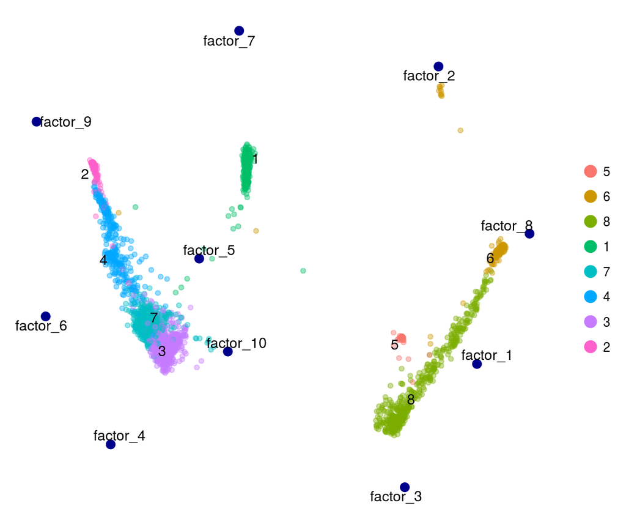

```r
color.seed <- 32566 ## Set seed for cluster colors
PlotSWNE(swne.embedding, alpha.plot = 0.4, sample.groups = clusters, do.label = T,
         label.size = 3.5, pt.size = 1.25, show.legend = T, seed = color.seed)
```

For now, let’s hide the factors by setting their names to the empty string `""`. We’ll interpret them later

```r
swne.embedding$H.coords$name <- ""
```

To help with interpreting these cell clusters, let’s pick some key PBMC genes to embed.

```r
genes.embed <- c("MS4A1", "GNLY", "CD3E", "CD14",
                 "FCER1A", "FCGR3A", "LYZ", "PPBP", "CD8A")
```

Since we only ran NMF on the overdispersed genes, we need to project the rest of the genes onto the NMF projection to get gene loadings for all genes.

```r
nmf.res$W <- ProjectFeatures(norm.counts, nmf.scores, loss = loss, n.cores = n.cores)
```

Now we can embed the key PBMC genes onto the visualization and remake the plot

```r
swne.embedding <- EmbedFeatures(swne.embedding, nmf.res$W, genes.embed, n_pull = 4)
```

Let’s make the SWNE plot with the key genes embedded. The closer a cell or a cluster is to a gene, the higher the expression level.

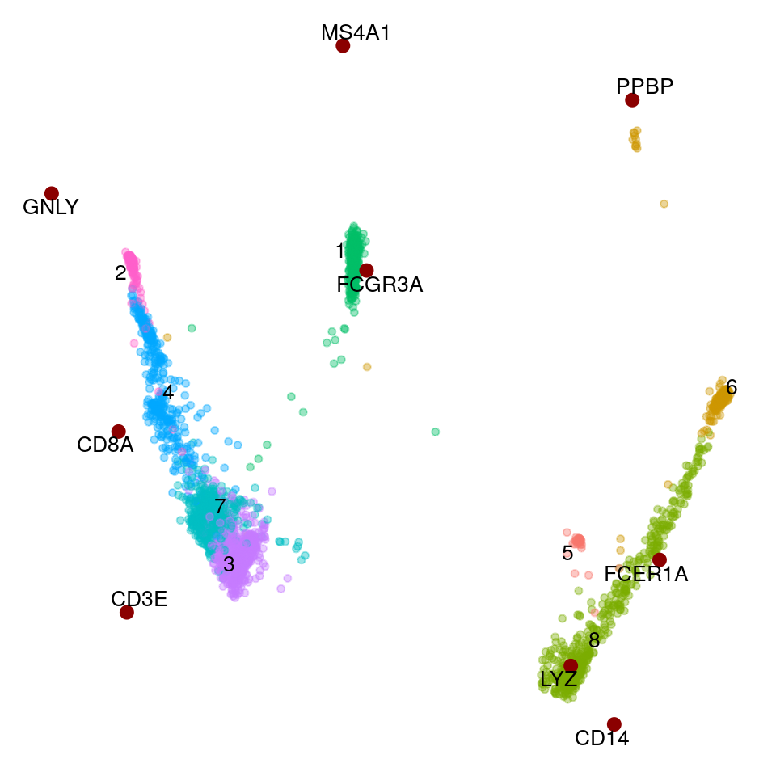

```r
PlotSWNE(swne.embedding, alpha.plot = 0.4, sample.groups = clusters, do.label = T,
         label.size = 3.5, pt.size = 1.25, show.legend = F, seed = color.seed)
```

We can validate this by overlaying the expression of one of these key genes onto the plot.

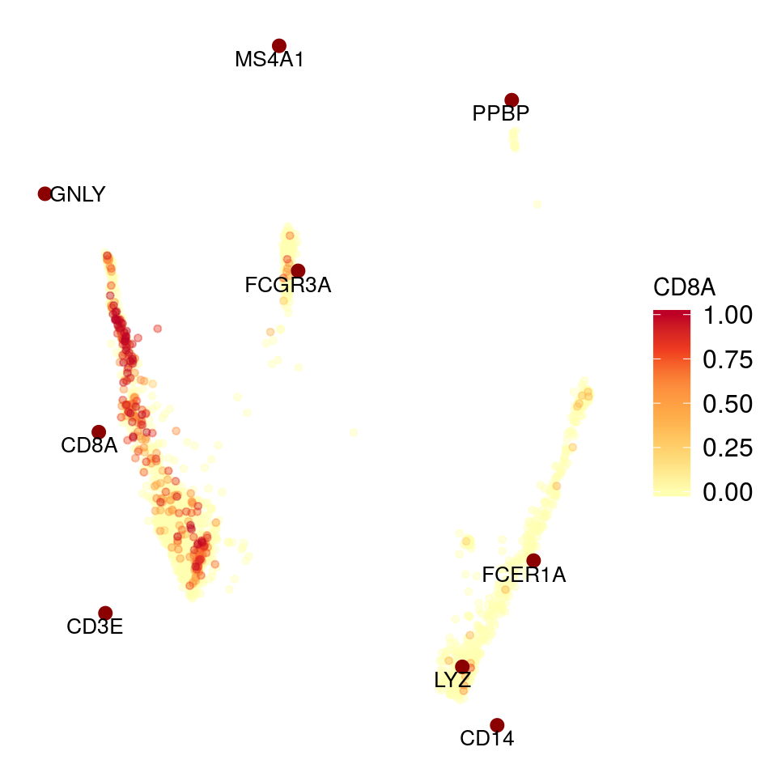

```r
gene.use <- "CD8A"
gene.expr <- norm.counts[gene.use,]
FeaturePlotSWNE(swne.embedding, gene.expr, gene.use, alpha.plot = 0.4, label.size = 3.5, pt.size = 1.25)
```

We can also make a t-SNE plot for comparison.

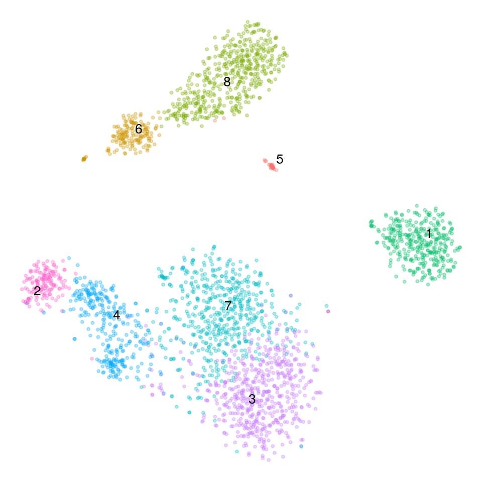

```r
tsne.scores <- p2$embeddings$PCA$tSNE
PlotDims(tsne.scores, sample.groups = clusters, pt.size = 0.75, label.size = 3.5, alpha = 0.3,
         show.legend = F, seed = color.seed, show.axes = F)
```

We can also interpret the factors by using the gene loadings matrix. Here, we extract the top 3 genes for each factor by gene loading. Since NMF tends to create a parts-based representation of the data, the factors often correspond to key biological processes or gene modules that explain the data.

```r
gene.loadings <- nmf.res$W
top.factor.genes.df <- SummarizeAssocFeatures(gene.loadings, features.return = 3)
head(top.factor.genes.df)
```

```
##   assoc_score feature   factor
## 1   1.3264970     LYZ factor_1
## 2   0.7561301    FTH1 factor_1
## 3   0.6170998     FTL factor_1
## 4   0.3831518    FTH1 factor_2
## 5   0.3338586    GPX1 factor_2
## 6   0.3301972     PF4 factor_2
```

And finally, we can make a heatmap to visualize the top factors for each gene

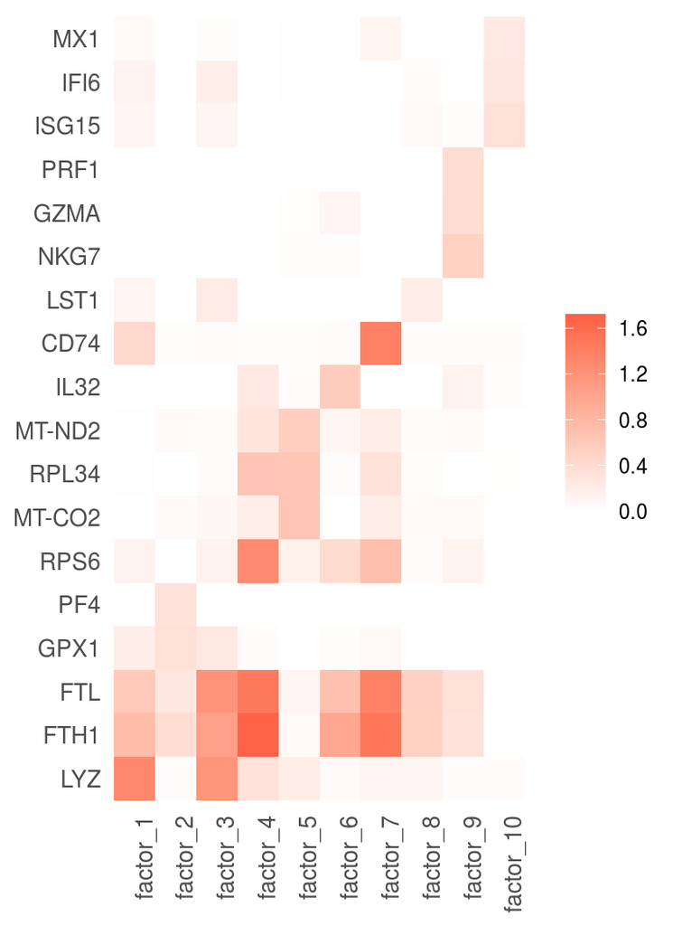

```r
gene.loadings.heat <- gene.loadings[unique(top.factor.genes.df$feature),]
ggHeat(gene.loadings.heat, clustering = "col")
```

Extract cluster colors for compatibility with other plotting methods (i.e. Monocle)

```r
color.mapping <- ExtractSWNEColors(swne.embedding, sample.groups = clusters, seed = color.seed)
color.mapping
```

```
##         7         1         8         2         4         6         3
## "#00BFC4" "#00BE67" "#7CAE00" "#FF61CC" "#00A9FF" "#CD9600" "#C77CFF"
##         5
## "#F8766D"
```